# Introduction to pestRisk: Modelling Pest Invasion Risk

Meriem Choukri

2026-06-14

## Overview

`pestRisk` implements a complete Species Distribution Modelling (SDM) workflow to predict the current invasion risk of agricultural pest species. The package covers every step from raw data download to publication-ready risk maps and automatic reports.

```
GBIF occurrences → clean → WorldClim → VIF selection
    → Random Forest + MaxEnt → evaluate → risk map → report
```

The three target species are:

| Species | Common name | Crop impact |
| --- | --- | --- |
| *Spodoptera frugiperda* | Fall armyworm | Maize, sorghum, rice |
| *Tuta absoluta* | Tomato leafminer | Tomato, pepper, potato |
| *Ceratitis capitata* | Mediterranean fruit fly | Citrus, stone fruits |

## Step 1 – Download GBIF occurrences

```r
library(pestRisk)

# Download fall armyworm records
occ_raw <- download_gbif(
  species = "Spodoptera frugiperda",
  limit   = 2000,
  year    = "2010,2023"
)

dim(occ_raw)
head(occ_raw[, c("species", "decimalLongitude", "decimalLatitude",
                  "year", "country")])
```

Using the built-in example dataset:

```r
library(pestRisk)
spodoptera_occ <- read.csv(
  system.file("extdata", "spodoptera_occ.csv", package = "pestRisk")
)
dim(spodoptera_occ)
```

```
#> [1] 200   8
```

## Step 2 – Clean occurrences

Spatial cleaning removes NA coordinates, impossible values, sea points, geographic outliers, and applies spatial thinning at 20 km to reduce sampling bias.

```r
clean_result <- clean_occurrences(
  occ       = spodoptera_occ,
  thin_dist = 20,    # 20 km thinning
  outlier_sd = 3,
  remove_sea = FALSE  # skipped here since we use simulated data
)
```

```
#>                                    step n_removed n_remaining
#>               1 – Remove NA coordinates         0         200
#>     2 – Remove impossible / Null Island         0         200
#>  3 – Remove spatial duplicates (4 d.p.)         0         200
#>          5 – Geographic outliers (3 SD)         0         200
#>            6 – Spatial thinning (20 km)         0         200
```

```r
print(clean_result$report)
```

```
#>                                     step n_removed n_remaining
#> 1              1 – Remove NA coordinates         0         200
#> 2    2 – Remove impossible / Null Island         0         200
#> 3 3 – Remove spatial duplicates (4 d.p.)         0         200
#> 4         5 – Geographic outliers (3 SD)         0         200
#> 5           6 – Spatial thinning (20 km)         0         200
```

```r
cat("\nFinal occurrences:", nrow(clean_result$data), "\n")
```

```
#>
#> Final occurrences: 200
```

## Step 3 – Download WorldClim variables

```r
# Download 6 key BIO variables at 10 arcmin for Africa + Mediterranean
africa_ext <- c(-20, 55, -40, 40)

clim <- download_worldclim(
  path   = "~/pestRisk_data",
  res    = "10",
  extent = africa_ext,
  vars   = c(1, 4, 5, 6, 12, 15)   # BIO1, BIO4, BIO5, BIO6, BIO12, BIO15
)
terra::plot(clim, main = names(clim))
```

**Why these 6 variables?**

| Variable | Ecological relevance for pest insects |
| --- | --- |
| BIO1 (Annual Mean Temp.) | Determines metabolic rate and development speed |
| BIO4 (Temp. Seasonality) | Controls overwinter survival |
| BIO5 (Max Temp. Hottest Month) | Heat stress upper threshold |
| BIO6 (Min Temp. Coldest Month) | Cold-kill threshold for populations |
| BIO12 (Annual Precip.) | Habitat moisture and host plant quality |
| BIO15 (Precip. Seasonality) | Drought stress and host phenology |

## Step 4 – Prepare predictors (VIF + Pearson)

```r
bg_pts <- generate_background_points(
  clim_stack     = clim,
  occurrences_sf = clean_result$data,
  n              = 5000,
  min_dist_km    = 50
)

prep <- prepare_predictors(
  occurrences_sf = clean_result$data,
  background_sf  = bg_pts,
  clim_stack     = clim,
  cor_threshold  = 0.75,
  vif_threshold  = 5
)

cat("Selected variables:", prep$selected_vars, "\n")
cat("VIF values:\n"); print(prep$vif_final)
```

Using the pre-built modelling dataset:

```r
spodoptera_model_data <- read.csv(
  system.file("extdata", "spodoptera_model_data.csv", package = "pestRisk")
)
str(spodoptera_model_data)
```

```
#> 'data.frame':    650 obs. of  6 variables:
#>  $ lon     : num  -13 -9.92 5.06 -14.92 13.08 ...
#>  $ lat     : num  -5.796 16.804 15.069 -23.422 -0.899 ...
#>  $ presence: int  1 1 1 1 1 1 1 1 1 1 ...
#>  $ BIO1    : num  232 227 231 228 208 ...
#>  $ BIO12   : num  958 780 1000 1031 1174 ...
#>  $ BIO15   : num  90.1 82 36.5 79.7 51 ...
```

```r
table(spodoptera_model_data$presence)
```

```
#>
#>   0   1
#> 500 150
```

## Step 5a – Train Random Forest

```r
rf_out <- train_rf_model(
  model_data = spodoptera_model_data,
  n_trees    = 200,
  balance    = TRUE,
  seed       = 42
)
```

```
#>  variable importance
#>     BIO12   44.75954
#>      BIO1   43.14146
#>     BIO15   23.62673
```

```r
print(rf_out$importance)
```

```
#>   variable importance
#> 2    BIO12   44.75954
#> 1     BIO1   43.14146
#> 3    BIO15   23.62673
```

## Step 5b – Train MaxEnt

```r
mx_out <- train_maxent(
  model_data      = spodoptera_model_data,
  reg_mult        = 1.5,
  feature_classes = "lqh",
  seed            = 42
)
```

## Step 6 – Evaluate models

```r
eval_out <- evaluate_models(
  rf_out, mx_out,
  model_names = c("Random Forest", "MaxEnt"),
  threshold   = 0.5,
  plot_roc    = TRUE
)
```

```
#>          Model   AUC Accuracy Sensitivity Specificity    F1
#>  Random Forest 0.930     0.84       0.895       0.824 0.723
#>         MaxEnt 0.951     0.89       0.684       0.952 0.743
```

```r
print(eval_out$metrics)
```

```
#>           Model   AUC Accuracy Sensitivity Specificity    F1
#> 1 Random Forest 0.930     0.84       0.895       0.824 0.723
#> 2        MaxEnt 0.951     0.89       0.684       0.952 0.743
```

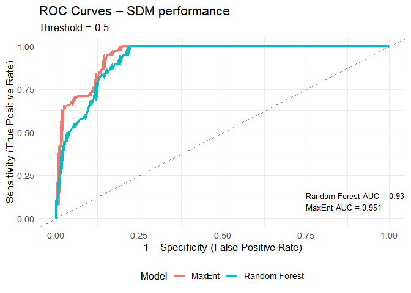

ROC curves for RF and MaxEnt models

```r
print(eval_out$roc_plot)
```

**Interpretation:**  
For pest surveillance, **Sensitivity** is more important than Specificity — a missed invasion zone (false negative) is more costly than unnecessary monitoring (false positive).

## Step 7 – Variable importance plot

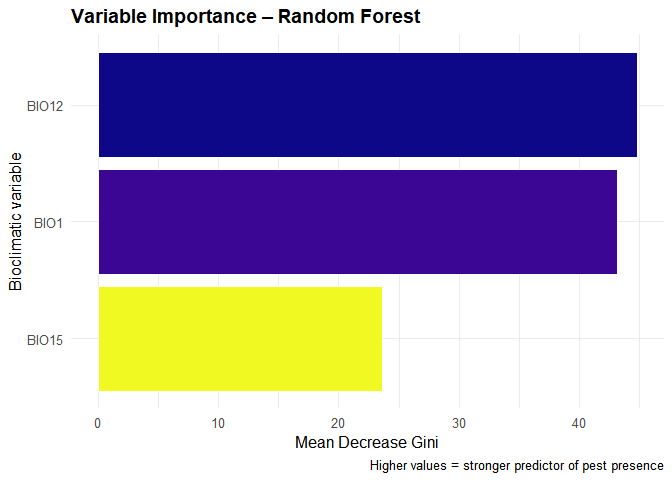

Random Forest variable importance

```r
plot_variable_importance(rf_out, type = "importance")
```

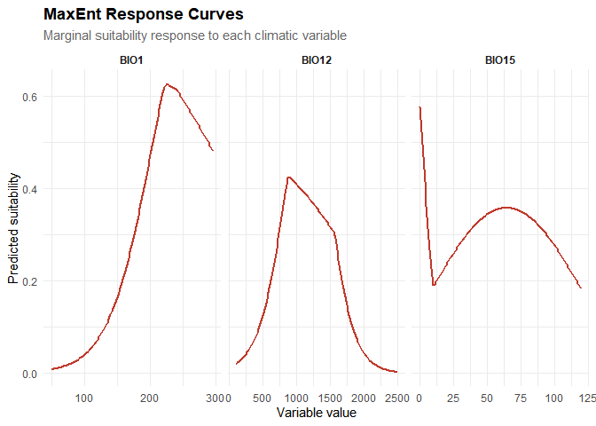

MaxEnt marginal response curves

```r
plot_variable_importance(mx_out, type = "response")
```

## Step 8 – Predict and visualise the risk map (real WorldClim data)

This section downloads a **small WorldClim extract** (Morocco + West Africa, 10 arcmin resolution, ~10 MB) so the full prediction pipeline can run end-to-end with real climate data.

```r
study_ext <- c(-20, 20, 0, 40)   # xmin, xmax, ymin, ymax (Morocco + W. Africa)

clim_small <- download_worldclim(
  path   = "worldclim_data",
  res    = "10",
  extent = study_ext,
  vars   = c(1, 12, 15)          # match rf_out$predictors exactly
)

clim_small
```

```
#> class       : SpatRaster
#> size        : 240, 240, 3  (nrow, ncol, nlyr)
#> resolution  : 0.1666667, 0.1666667  (x, y)
#> extent      : -20, 20, 0, 40  (xmin, xmax, ymin, ymax)
#> coord. ref. : lon/lat WGS 84 (EPSG:4326)
#> source(s)   : memory
#> names       :      BIO1, BIO12,      BIO15
#> min values  :  6.303792,     1,  16.372847
#> max values  : 30.708927,  4347, 186.499786
```

```r
risk <- predict_risk_map(rf_out, clim_small, breaks = c(0.33, 0.66))
```

```
#>   Low (): 100%
```

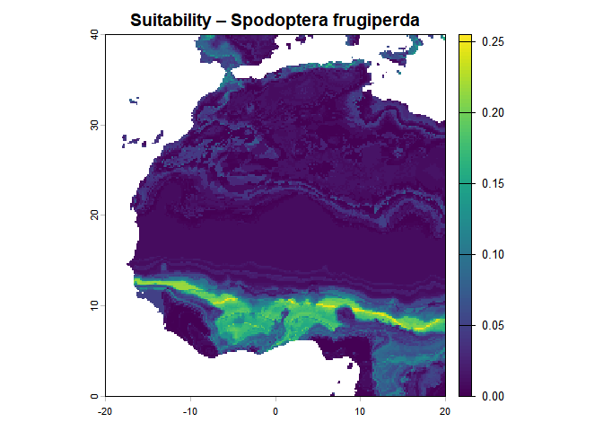

```r
# Quick base-R preview
terra::plot(risk$suitability, main = "Suitability – Spodoptera frugiperda")
```

```r
# Keep only the occurrence points that fall inside the study extent
occ_sub <- spodoptera_occ[
  spodoptera_occ$decimalLongitude >= study_ext[1] &
  spodoptera_occ$decimalLongitude <= study_ext[2] &
  spodoptera_occ$decimalLatitude  >= study_ext[3] &
  spodoptera_occ$decimalLatitude  <= study_ext[4], ]

occ_sf <- sf::st_as_sf(occ_sub,
                       coords = c("decimalLongitude", "decimalLatitude"),
                       crs = 4326)
nrow(occ_sf)
```

```
#> [1] 43
```

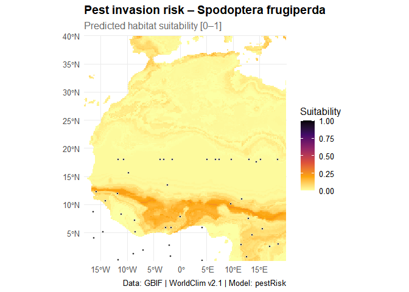

Continuous habitat suitability map

```r
plot_risk_map(
  risk,
  type            = "continuous",
  occurrences_sf  = occ_sf,
  species_name    = "Spodoptera frugiperda",
  country_borders = FALSE
)
```

[figure not shown]

```r
plot_risk_map(
  risk,
  type            = "classified",
  species_name    = "Spodoptera frugiperda",
  country_borders = FALSE
)
```

```r
freq_tbl <- terra::freq(risk$risk_class)
freq_tbl$pct <- round(100 * freq_tbl$count / sum(freq_tbl$count), 1)
print(freq_tbl)
```

```
#>   layer value count pct
#> 1     1   Low 39758 100
```

## Step 9 – Country risk summary

```r
country_tbl <- summarize_country_risk(risk, top_n = 10)
```

```
#>  risk_rank                   region mean_suitability pct_high_risk
#>          1                   Greece           0.1575             0
#>          2                    Benin           0.1452             0
#>          3                     Togo           0.1384             0
#>          4                    Ghana           0.1228             0
#>          5            Côte d'Ivoire           0.1208             0
#>          6                  Albania           0.1200             0
#>          7                    Malta           0.1100             0
#>          8 Central African Republic           0.0878             0
#>          9            Guinea-Bissau           0.0868             0
#>         10                  Nigeria           0.0761             0
```

```r
print(country_tbl[, c("risk_rank", "region", "mean_suitability", "pct_high_risk")])
```

```
#>    risk_rank                   region mean_suitability pct_high_risk
#> 1          1                   Greece           0.1575             0
#> 2          2                    Benin           0.1452             0
#> 3          3                     Togo           0.1384             0
#> 4          4                    Ghana           0.1228             0
#> 5          5            Côte d'Ivoire           0.1208             0
#> 6          6                  Albania           0.1200             0
#> 7          7                    Malta           0.1100             0
#> 8          8 Central African Republic           0.0878             0
#> 9          9            Guinea-Bissau           0.0868             0
#> 10        10                  Nigeria           0.0761             0
```

**Interpretation:** Countries with a high `mean_suitability` and high `pct_high_risk` should be prioritised for fall armyworm monitoring programmes.

## Step 10 – Generate automatic report

```r
generate_report(
  species_name    = "Spodoptera frugiperda",
  occurrences_sf  = clean_result$data,
  clean_report    = clean_result$report,
  eval_results    = eval_out,
  risk_map_obj    = risk,
  country_summary = country_tbl,
  model_obj       = rf_out,
  output_file     = "Spodoptera_frugiperda_risk_report.html",
  author          = "Meriem Benali – FSDM Fès"
)
```

## Step 10 – New features: ensemble model & degree-day risk

### 10a. Ensemble suitability (RF + MaxEnt)

`ensemble_suitability()` combines both models, weighted by their AUC scores from Step 6.

```r
mx_risk <- predict_risk_map(mx_out, clim_small, breaks = c(0.33, 0.66))
```

```
#>   Low (): 100%
```

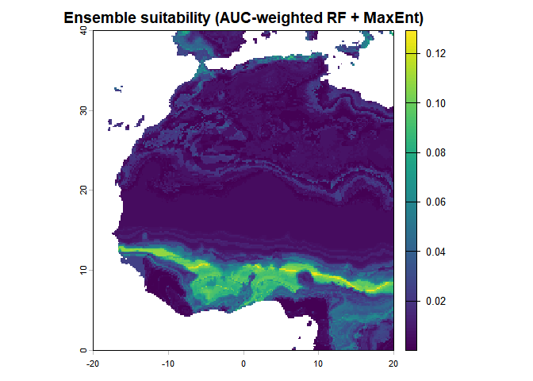

```r
rf_auc <- eval_out$metrics$AUC[eval_out$metrics$Model == "Random Forest"]
mx_auc <- eval_out$metrics$AUC[eval_out$metrics$Model == "MaxEnt"]

ens <- ensemble_suitability(
  rf_risk = risk,
  mx_risk = mx_risk,
  rf_auc  = rf_auc,
  mx_auc  = mx_auc
)

terra::plot(ens$ensemble_suitability,
            main = "Ensemble suitability (AUC-weighted RF + MaxEnt)")
```

### 10b. Thermal degree-day risk (generations per year)

`degree_days_risk()` converts WorldClim monthly mean temperature into an estimate of how many pest generations can be completed per year — a direct measure of invasion *intensity*, not just presence/absence.

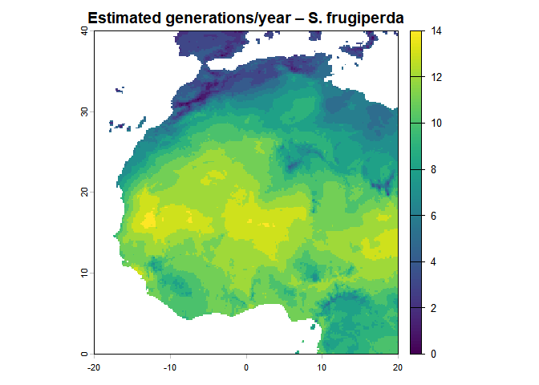

```r
tavg <- geodata::worldclim_global(var = "tavg", res = 10,
                                   path = "worldclim_data")
tavg_small <- terra::crop(tavg, terra::ext(study_ext))

dd <- degree_days_risk(
  clim_stack      = tavg_small,
  t_base          = 12.5,   # S. frugiperda lower threshold
  n_gen_threshold = 450
)

terra::plot(dd$n_generations,
            main = "Estimated generations/year – S. frugiperda")
```

**Interpretation:** Pixels with **≥ 3 generations/year** represent zones where chemical control is likely to fail due to rapid pest reproduction — these areas require integrated pest management (IPM) strategies.

## Complete one-liner workflow

```r
library(pestRisk)

species    <- "Tuta absoluta"
study_ext  <- c(-20, 55, -40, 40)
data_path  <- "~/pestRisk_data"

# 1. Download
occ   <- download_gbif(species, limit = 1500, year = "2010,2023")
clim  <- download_worldclim(path = data_path, res = "10",
                              extent = study_ext)

# 2. Clean
clean <- clean_occurrences(occ)

# 3. Background
bg <- generate_background_points(clim, clean$data, n = 5000)

# 4. Predictors
prep <- prepare_predictors(clean$data, bg, clim)

# 5. Models
rf_model <- train_rf_model(prep$model_data)
mx_model <- train_maxent(prep$model_data)

# 6. Evaluate
eval <- evaluate_models(rf_model, mx_model,
                         model_names = c("RF","MaxEnt"))

# 7. Map
risk <- predict_risk_map(rf_model, clim)

# 8. Summary
ctry <- summarize_country_risk(risk)

# 9. Report
generate_report(species, clean$data, clean$report, eval, risk, ctry,
                rf_model, output_file = "tuta_absoluta_report.html")
```